# Homework 5. CNN

M. Papkov, I. Pavlov

### Данные

Данные, которые легли в основу этой домашки взяты из статьи http://image.diku.dk/lauges/publications/Sorensen2010.pdf. Авторы данной статьи занимались квантификацией легочной эмфиземы, в связи с чем у этих ребят было некоторое количество изображений компьютерной томографии легких.

Мы будем классифицировать кусочки изображений на три класса: normal tissue (NT), centrilobular emphysema (CLE), paraseptal emphysema (PSE).

Вообще все эти слайсы и патчи от реальных пациентов, и есть файлы, которые описывают это всё дело, но нас в этой работе будут интересовать только patches и patch_labels. Прочитаем их

```r
patches <- dir("./patches", full.names = T)
patch_labels <- read.csv("./patch_labels.csv", header = F)
```

### Библиотеки

Для работы с изображениями будем использовать библиотеку OpenImageR.

```r
library(OpenImageR)
library(mxnet)
```

### Увеличение количества картинок

В папке “patches” находятся 168 jpg изображений размера 61x61. Этого количества, конечно, мало, поэтому было бы неплохо это количество увеличить. Как будем увеличивать? Картинку можно повернуть на какое-то количество градусов и зеркально отразить. Можно сдвинуть картинку на несколько пикселей. А ещё было бы неплохо применить ZCA whitening –– это такое нормализующее преобразование, которое часто используется в обучении нейронных сетей.

#### Augmentation

Первой частью задания будет искусственное увеличение датасета с помощью функции Augmentation в пакете OpenImageR: хочется взять и каждую картинку случайно повернуть и немного сдвинуть и проделать это где-то ~50 раз.

Пример использования функции:

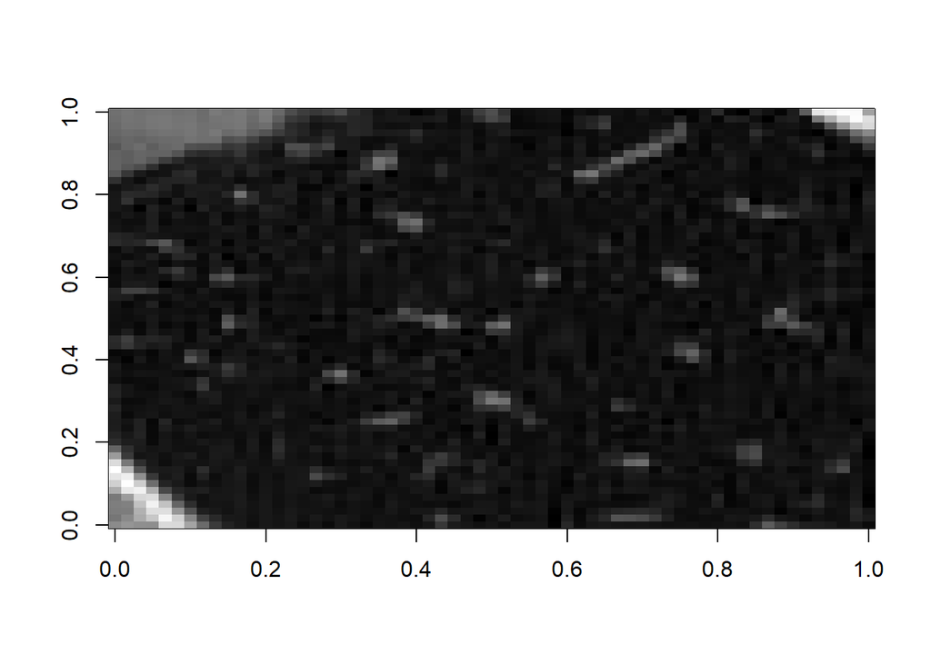

```r
# taken from https://stackoverflow.com/questions/22509106/converting-a-matrix-into-a-gray-scale-image-in-r
grays <- rgb(red = 0:255/255, blue = 0:255/255, green = 0:255/255)

# Source image
patch <- readImage(patches[1])
image(patch, col=grays)
```

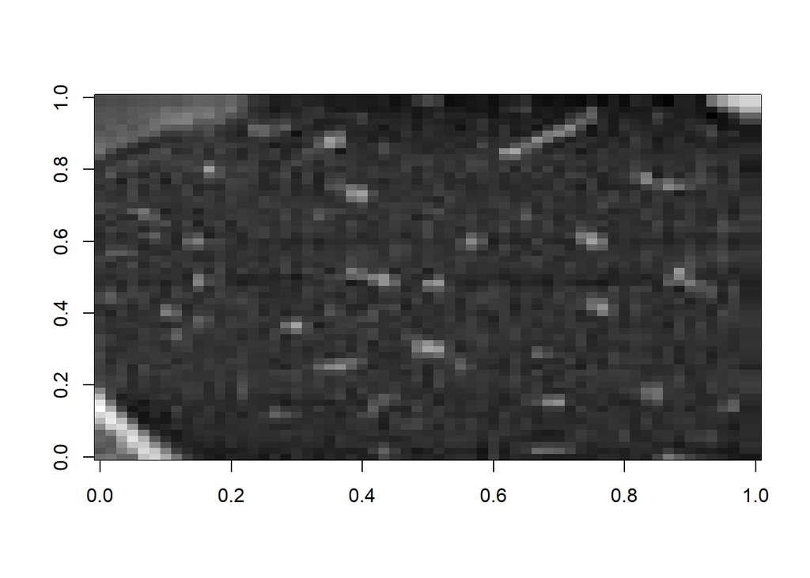

```r
# ZCA only
patchAugmented <- Augmentation(patch, zca_comps = 30, zca_epsilon = 0.1, threads = 1, verbose = F)
image(patchAugmented, col=grays)
```

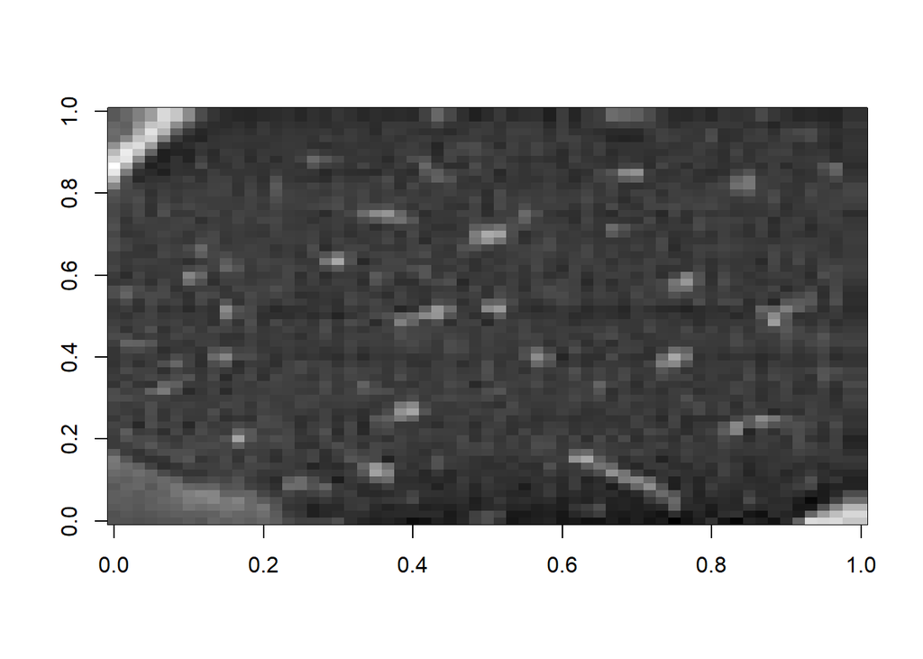

```r
# ZCA only + flip
patchAugmented <- Augmentation(patch, flip_mode = "horizontal",
                                 zca_comps = 30, zca_epsilon = 0.1, threads = 1, verbose = F)
image(patchAugmented, col=grays)
```

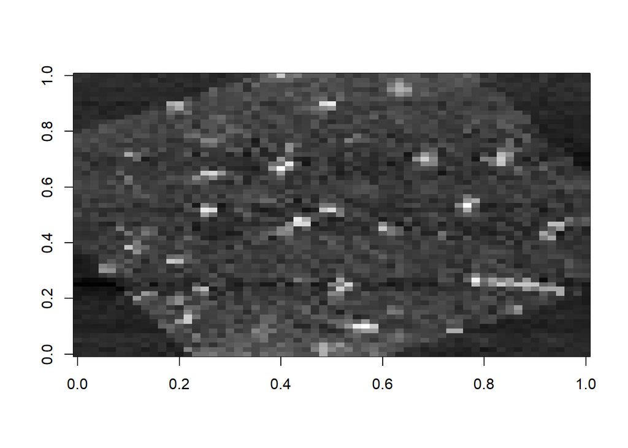

```r
# ZCA only + flip + rotation 30 degrees counterclockwise
patchAugmented <- Augmentation(patch, flip_mode = "horizontal",
             rotate_angle = 30, rotate_method = 'bilinear',
             zca_comps = 30, zca_epsilon = 0.1, threads = 1, verbose = F)
image(patchAugmented, col=grays)
```

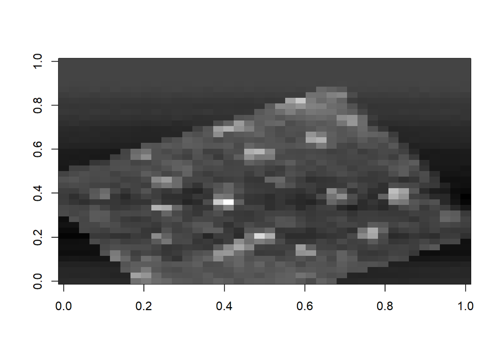

```r
# ZCA only + flip + rotation 30 degrees counterclockwise + shift 10 pixels comlumns and 5 pixels rows
patchAugmented <- Augmentation(patch, flip_mode = "horizontal",
             shift_cols = 10, shift_rows = 5,
             rotate_angle = 30, rotate_method = 'bilinear',
             zca_comps = 30, zca_epsilon = 0.1, threads = 1, verbose = F,
             resiz_width = 40, resiz_height = 40, resiz_method = "bilinear")
image(patchAugmented, col=grays)
```

Проведем аугментацию всех изображений, понизим размерность, сохраним результат на диск (это долго).

```r
set.seed(88)

dir.create("./patches_augmented_40/")

s <- sapply(patches, function(p) {
  print(p)
  patch <- readImage(p)
  degrees <- sample(seq(0, 360, 5), 50)
  shift_r <- sample(seq(-7, 7, 1), 50, replace = T)
  shift_c <- sample(seq(-7, 7, 1), 50, replace = T)
  flip_m <- sample(c('horizontal', 'vertical'), 50, replace = T)
  s <- sapply(1:50, function(x) {
    patchAugmented <- Augmentation(patch, flip_mode = flip_m[x],
                                   shift_cols = shift_c[x], shift_rows = shift_r[x],
                                   rotate_angle = degrees[x], rotate_method = 'bilinear',
                                   zca_comps = 30, zca_epsilon = 0.1, threads = 1, verbose = F,
                                   resiz_width = 40, resiz_height = 40, resiz_method = "bilinear")

    writeImage(patchAugmented,
               file_name = paste0("./patches_augmented_40/",
                                  gsub("[.]jpg", "", strsplit(p, split = "/")[[1]][3]),
                                  "_augmented_", x, ".jpg"))
    })
})
```

Создадим сет

```r
# Не забудем про лейблы
patch_aug_labels <- as.data.frame(as.numeric(sapply(patch_labels[[1]], function(l) rep(l, 50))))

data.dims <- dim(patch_aug_labels)
img.size <- 40
features <- img.size * img.size

dataset.size <- data.dims[1]
nn.data.x <- matrix(0, nrow=dataset.size, ncol=features)
nn.data.y <- patch_aug_labels[[1]]

for (i in 1:168) {
  for (j in 1:50) {
    patch <- readImage(sprintf("./patches_augmented_40/patch%s_augmented_%s.jpg", i, j))
    nn.data.x[(i-1)*50 + j, ] <- as.numeric(patch)
  }
}


nn.data.x[1:12, 1:5]
```

```
##              [,1]        [,2]        [,3]        [,4]        [,5]
##  [1,] 0.003921569 0.003921569 0.003921569 0.003921569 0.003921569
##  [2,] 0.003921569 0.003921569 0.003921569 0.003921569 0.003921569
##  [3,] 0.035294118 0.000000000 0.000000000 0.015686275 0.000000000
##  [4,] 0.000000000 0.003921569 0.015686275 0.019607843 0.015686275
##  [5,] 0.003921569 0.003921569 0.003921569 0.003921569 0.003921569
##  [6,] 0.003921569 0.003921569 0.003921569 0.003921569 0.003921569
##  [7,] 0.019607843 0.000000000 0.125490196 0.196078431 0.129411765
##  [8,] 0.023529412 0.000000000 0.000000000 0.003921569 0.007843137
##  [9,] 0.000000000 0.000000000 0.000000000 0.000000000 0.000000000
## [10,] 0.000000000 0.019607843 0.011764706 0.000000000 0.000000000
## [11,] 0.003921569 0.003921569 0.003921569 0.003921569 0.003921569
## [12,] 0.027450980 0.000000000 0.003921569 0.007843137 0.000000000
```

```r
nn.data.y[1:12]
```

```
##  [1] 1 1 1 1 1 1 1 1 1 1 1 1
```